# ZEAL/BZea DTS GWAS + JLM on the SNP50K panel — FDR ≤ 0.05

Days-to-silk sibling of the DTA notebook: the same SNP50K ancestry pipeline and flowering candidate set, with per-field SpATS days-to-silk BLUEs as the phenotype. Significance is Benjamini–Hochberg FDR ≤ 0.05 (per-scan q-values): the Manhattan line is the −log₁₀P at which BH q = 0.05, and candidate/peak calls report q.

Author

Fausto Rodríguez-Zapata

Published

July 9, 2026

**ImportantGenotype at 0.4× skim: why ancestry, not per-SNP**

SNP50K is 51,991 teosinte-vs-B73 sites pileup-genotyped at ~0.4× — hard genotypes are unusable (70% missing, ~0% hom-ALT), so ancestry is inferred from the per-sample allele **counts**. The **per-SNP genotype (bcftools HWE-posterior) (Panel B)** is therefore λ_GC-deflated (sparse mean-imputation); the **RTIGER ancestry mosaic (Panel C)** is the usable, block-smoothed genotype (teosinte presence 0.111, matching the established BzeaSeq ~0.101). This is the SNP50K-specific reason ancestry inference is mandatory.

As in DTA, **K = teosinte-ancestry relatedness is collinear with the flowering QTL**, so the mixed model absorbs the very signal it protects — the flowering candidates (`ZmCCT10`, `ZCN8`) are suppressed under MLM. The DTS QTL are therefore the province of **JLM** (nested-in-family stepwise), not the MLM Manhattan.

```r
library(here)
library(data.table)
library(ggplot2)
library(fastman)
library(ggrepel)
library(ggtext)
library(scales)
library(cowplot)
source(here("scripts/teonam_notebook_plots.R")) # shared: plot_manhattan/lollipop, lambda_gc, LOD
```

```r
mlm <- fread(here("data/zeal/dts_gwas_mlm_rtiger_mosaic_donor_accession_snp50k.csv")) # Panel C
gt <- fread(here("data/zeal/dts_gwas_mlm_hwe_post_gt_donor_accession_snp50k.csv")) # Panel B
ols <- fread(here("data/zeal/dts_gwas_ols_donor_accession_snp50k.csv"))[is.finite(P) & P > 0]
overlap <- here("results/sim/zeal/dts_candidate_overlap.csv")
lam <- function(p) {
  p <- p[is.finite(p) & p > 0 & p <= 1]
  round(median(qchisq(p, 1, lower.tail = FALSE)) / qchisq(0.5, 1), 2)
}
ALPHA <- 0.05
fdr_lod <- function(p, alpha = ALPHA) {
  p <- p[is.finite(p) & p > 0]
  q <- p.adjust(p, "BH")
  if (!any(q <= alpha)) {
    return(NA_real_)
  }
  -log10(max(p[q <= alpha]))
}
qval <- function(p) p.adjust(p, "BH") # BH q-values aligned to p
```

**NoteSignificance = Benjamini–Hochberg FDR ≤ 0.05**

Every Manhattan’s dotted line is drawn at the **−log₁₀P where BH q = 0.05** for that scan; a marker is significant iff its BH q ≤ 0.05. If no marker passes FDR, no line is drawn. Candidate/peak tables report q.

## Candidate genes: closest marker vs window-max marker

For each maize flowering candidate (B73 v5), the closest marker to the gene body vs the highest −log₁₀P marker within ±500 kb in the RTIGER-mosaic **MLM (Taxon+K)** scan (Panel C). The same v5 flowering candidates as DTA (these are maize genes; teosinte introgression at them drives flowering time in both sexes).

```r
sc <- copy(mlm)[is.finite(P) & P > 0][, logP := -log10(P)][, q := qval(P)]
gg <- fread(here("data/teonam/dts_candidate_genes.tsv"))
gg[, chr := as.integer(chr)][, qtl := ifelse(qtl_chen2019 == "" | is.na(qtl_chen2019), paste0("DTS(chr", chr, ")"), qtl_chen2019)]
WIN <- 5e5
ctab <- rbindlist(lapply(seq_len(nrow(gg)), function(i) {
  ch <- gg$chr[i]
  s <- gg$start[i]
  e <- gg$end[i]
  m <- sc[CHR == ch]
  if (!nrow(m)) {
    return(NULL)
  }
  d <- pmax(0L, pmax(s - m$BP, m$BP - e))
  kc <- which.min(d)
  w <- m[BP >= s - WIN & BP <= e + WIN]
  kw <- if (nrow(w)) which.max(w$logP) else NA
  data.table(
    gene = gg$symbol[i], QTL = gg$qtl[i], chr = ch, `gene start (v5)` = s,
    `closest Δstart (bp)` = m$BP[kc] - s, `closest -log10P` = round(m$logP[kc], 2),
    `window-max -log10P` = if (nrow(w)) round(w$logP[kw], 2) else NA_real_,
    `window-max q (BH)` = if (nrow(w)) signif(w$q[kw], 2) else NA_real_,
    `FDR<=0.05` = if (nrow(w)) w$q[kw] <= ALPHA else NA
  )
}))
setorder(ctab, chr, `gene start (v5)`)
knitr::kable(ctab,
  format.args = list(big.mark = ","),
  caption = "DTS candidates (B73 v5): closest vs window-max (±500 kb) marker, RTIGER-mosaic MLM (Taxon+K) scan, with Benjamini–Hochberg q at the window-max marker."
)
```

DTS candidates (B73 v5): closest vs window-max (±500 kb) marker, RTIGER-mosaic MLM (Taxon+K) scan, with Benjamini–Hochberg q at the window-max marker.

| gene | QTL | chr | gene start (v5) | closest Δstart (bp) | closest -log10P | window-max -log10P | window-max q (BH) | FDR<=0.05 |
| --- | --- | --- | --- | --- | --- | --- | --- | --- |
| zagl1 | DTS(chr1) | 1 | 283,849,414 | 12,915 | 0.67 | 0.84 | 0.790 | FALSE |
| zmads69 | DTS(chr3) | 3 | 161,172,047 | 29,298 | 0.28 | 0.48 | 0.920 | FALSE |
| zcn12 | DTA3.2 | 3 | 202,794,887 | 3,509 | 0.68 | 0.85 | 0.790 | FALSE |
| tu1 | DTA4.1 | 4 | 183,877,026 | -2,231 | 0.84 | 0.84 | 0.790 | FALSE |
| zmm31 | DTA5.1 | 5 | 7,374,462 | -50,600 | 0.43 | 0.73 | 0.840 | FALSE |
| si1 | DTA6.1 | 6 | 94,458,037 | 12,722 | 0.68 | 0.68 | 0.860 | FALSE |
| zag1 | DTA6.2 | 6 | 142,692,209 | 65,043 | 0.97 | 1.26 | 0.580 | FALSE |
| dlf1 | DTA7.2 | 7 | 184,528,042 | -547,303 | 1.23 | NA | NA | NA |
| zcn8 | DTS(chr8) | 8 | 126,678,681 | -57,791 | 0.28 | 0.31 | 0.970 | FALSE |
| zmcct9 | DTS(chr9) | 9 | 120,960,326 | 7,897 | 0.30 | 0.37 | 0.960 | FALSE |
| zmcct10 | DTS(chr10) | 10 | 96,175,873 | -2,308 | 1.66 | 3.12 | 0.028 | TRUE |

## OLS → MLM: the flowering confound and structure control

The fixed-effect OLS (Taxon + marker, no K) vs the MLM (Taxon + K) on the RTIGER mosaic, same fixed part. OLS is intrinsically inflated (ancestry-block LD); K deflates λ toward 1 **and** collapses the flowering peaks (`ZmCCT10`), the ancestry-QTL confound.

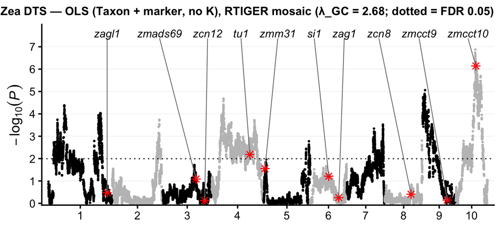

```r
plot_manhattan(ols,
  sprintf("ZEAL/BZea DTS — OLS (Taxon + marker, no K), RTIGER mosaic (λ_GC = %.2f; dotted = FDR 0.05)", lam(ols$P)),
  overlap_csv = overlap, lod = fdr_lod(ols$P),
  out_png = here("results/sim/zeal/dts_gwas_ols_manhattan_fdr_snp50k.png")
)
```

```r
lam_tab <- data.table(
  model = c("OLS (Taxon + marker, no K)", "MLM (Taxon + K)"),
  markers = c(nrow(ols), nrow(mlm)),
  lambda_GC = c(lam(ols$P), lam(mlm$P)),
  `n FDR<=0.05` = c(sum(qval(ols$P) <= ALPHA), sum(qval(mlm$P) <= ALPHA)),
  max_logP = round(c(max(-log10(ols$P)), max(-log10(mlm$P))), 2)
)
knitr::kable(lam_tab, caption = "OLS vs MLM on the RTIGER mosaic (same Taxon fixed part): K deflates genomic inflation; n markers at BH FDR ≤ 0.05.")
```

OLS vs MLM on the RTIGER mosaic (same Taxon fixed part): K deflates genomic inflation; n markers at BH FDR ≤ 0.05.

| model | markers | lambda_GC | n FDR<=0.05 | max_logP |
| --- | --- | --- | --- | --- |
| OLS (Taxon + marker, no K) | 48900 | 2.68 | 9911 | 6.88 |
| MLM (Taxon + K) | 48900 | 1.06 | 1428 | 13.74 |

```r
ov <- fread(overlap)
peak_at <- function(scan, ch, s) {
  w <- scan[CHR == ch & abs(BP - s) <= 5e5 & is.finite(P) & P > 0]
  if (!nrow(w)) NA_real_ else round(max(-log10(w$P)), 2)
}
cmp <- ov[, .(
  gene = symbol, chr,
  `OLS peak` = mapply(peak_at, list(ols), chr, start),
  `MLM peak` = mapply(peak_at, list(mlm), chr, start)
)]
cmp[, `drop (OLS−MLM)` := round(`OLS peak` - `MLM peak`, 2)]
setorder(cmp, -`OLS peak`)
knitr::kable(cmp, caption = "Local peak -log10P (±500 kb) per candidate: OLS vs MLM. K suppresses the ancestry-collinear flowering peaks.")
```

Local peak -log10P (±500 kb) per candidate: OLS vs MLM. K suppresses the ancestry-collinear flowering peaks.

| gene | chr | OLS peak | MLM peak | drop (OLS−MLM) |
| --- | --- | --- | --- | --- |
| dlf1 | 7 | NA | NA | NA |
| zmcct10 | 10 | 6.14 | 3.12 | 3.02 |
| tu1 | 4 | 2.18 | 0.84 | 1.34 |
| zmm31 | 5 | 1.55 | 0.73 | 0.82 |
| si1 | 6 | 1.21 | 0.68 | 0.53 |
| zmads69 | 3 | 1.09 | 0.48 | 0.61 |
| zagl1 | 1 | 0.47 | 0.84 | -0.37 |
| zcn8 | 8 | 0.41 | 0.31 | 0.10 |
| zag1 | 6 | 0.26 | 1.26 | -1.00 |
| zmcct9 | 9 | 0.15 | 0.37 | -0.22 |
| zcn12 | 3 | 0.13 | 0.85 | -0.72 |

## JLM QTL genomic distribution (Panel A)

DTS QTL from JLM (TASSEL StepwiseOLS, nested in taxon, enter/exit P=1e-4=LOD4). Model-independent — the primary flowering analysis, as in Chen 2019.

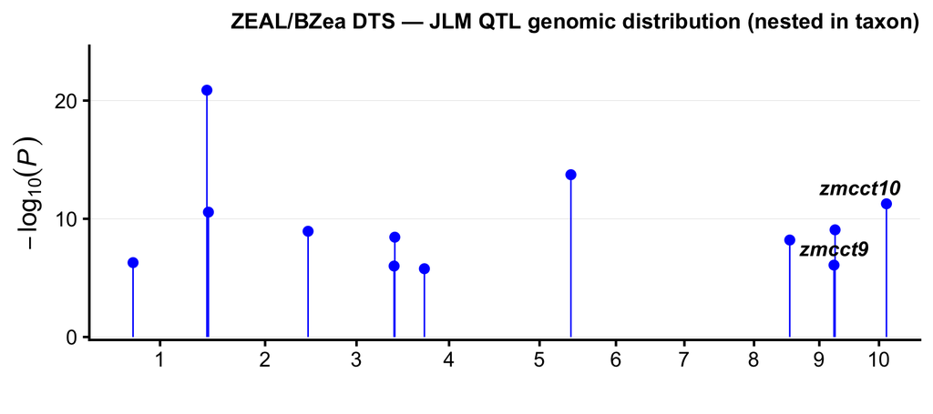

```r
p_lolli <- plot_lollipop(
  here("results/sim/zeal/tassel/dts_jlm_native1.txt"), mlm,
  "ZEAL/BZea DTS — JLM QTL genomic distribution (nested in taxon)",
  overlap_csv = overlap, label_genes = c("zcn8", "zcn12", "zmcct9", "zmcct10", "dlf1", "tu1"),
  out_png = here("results/sim/zeal/dts_jlm_lollipop_snp50k.png")
)
p_lolli
```

## MLM (Taxon + K), RTIGER ancestry mosaic (Panel C)

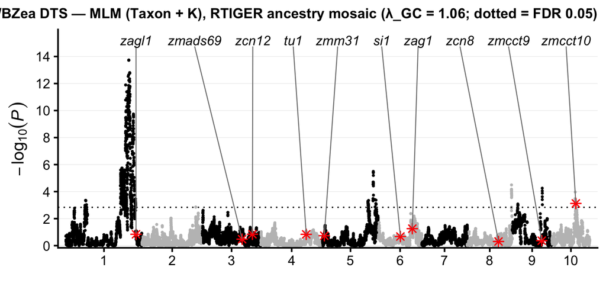

```r
p_mlm <- plot_manhattan(mlm,
  sprintf("ZEAL/BZea DTS — MLM (Taxon + K), RTIGER ancestry mosaic (λ_GC = %.2f; dotted = FDR 0.05)", lam(mlm$P)),
  overlap_csv = overlap, lod = fdr_lod(mlm$P), out_png = here("results/sim/zeal/dts_gwas_mlm_rtiger_mosaic_manhattan_fdr_snp50k.png")
)
p_mlm
```

```r
cat(sprintf("%d markers pass FDR <= 0.05 (BH); FDR line at -log10P = %s\n", sum(qval(mlm$P) <= ALPHA), ifelse(is.na(fdr_lod(mlm$P)), "NA (none)", sprintf("%.2f", fdr_lod(mlm$P)))))
```

```
1428 markers pass FDR <= 0.05 (BH); FDR line at -log10P = 2.84
```

## Composite (A: JLM · B: per-SNP MLM · C: RTIGER-mosaic MLM)

Panel B (per-SNP genotype (bcftools HWE-posterior)) is λ_GC-deflated but catches sharp SNP hits (`ZCN8`) the mosaic block-terraces away. Panel C (the ancestry mosaic) is the usable, well-calibrated genotype. The B↔︎C contrast is the notebook’s per-SNP-scatter vs ancestry-block-smoothing.

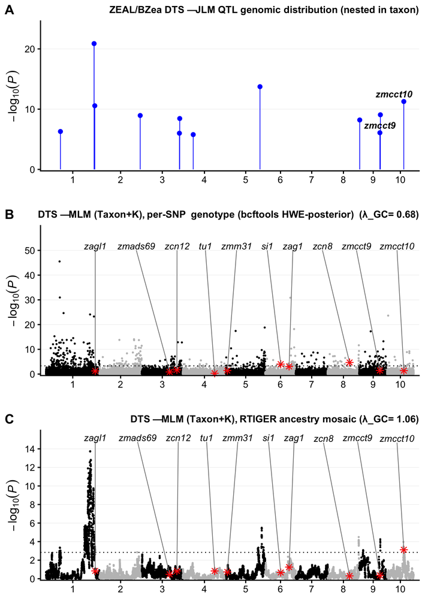

```r
p_B <- plot_manhattan(gt,
  sprintf("DTS — MLM (Taxon+K), per-SNP genotype (bcftools HWE-posterior) (λ_GC = %.2f)", lam(gt$P)),
  overlap_csv = overlap, lod = fdr_lod(gt$P)
)
p_C <- plot_manhattan(mlm,
  sprintf("DTS — MLM (Taxon+K), RTIGER ancestry mosaic (λ_GC = %.2f)", lam(mlm$P)),
  overlap_csv = overlap, lod = fdr_lod(mlm$P)
)
composite <- cowplot::plot_grid(p_lolli, p_B, p_C, ncol = 1, labels = c("A", "B", "C"), label_size = 20, align = "v", axis = "lr")
ggsave(here("results/sim/zeal/dts_composite_snp50k.png"), composite, width = 9, height = 13, dpi = 200, bg = "white")
composite
```

## Multi-caller DTS scan (control · nNIL · RTIGER · LB-Impute · binhmm)

The same DTS MLM (Taxon+K) scan on each ancestry caller’s recovered genotypes, at the real ~0.4× depth. Caller reliability at low coverage: the block/bin-aggregated callers (RTIGER per-donor segments; binhmm 1 Mb bins) recover the correct teosinte fraction (~0.10), while per-SNP calling (control) and the fresh per-SNP HMM recalls (nNIL, LB-Impute) **under-call** and give λ-deflated scans. Caller genotypes are population-level and trait-independent; only the phenotype (DTS) changes.

```r
callers <- c(control = "hwe_post_gt", nNIL = "nnil_mosaic", RTIGER = "rtiger_mosaic", `LB-Impute` = "lbimpute_mosaic", binhmm = "binhmm_mosaic")
tb1 <- fread(here("data/teonam/dts_candidate_genes.tsv"))[symbol == "zmcct10"]
ctab2 <- rbindlist(lapply(names(callers), function(nm) {
  g <- callers[[nm]]
  sc <- fread(here(sprintf("data/zeal/dts_gwas_mlm_%s_donor_accession_snp50k.csv", g)))
  mf <- here(sprintf("data/zeal/zeal_%s.rds", g))
  pres <- if (file.exists(mf)) {
    st <- readRDS(mf)$state
    round(mean(st %in% c(1L, 2L), na.rm = TRUE), 3)
  } else {
    NA_real_
  }
  sc <- sc[is.finite(P) & P > 0]
  z <- sc[CHR == tb1$chr & abs(BP - tb1$start) <= 5e5]
  data.table(
    caller = nm, `teosinte presence` = pres, lambda_GC = lam(sc$P),
    `n FDR<=0.05` = sum(qval(sc$P) <= ALPHA),
    `zmcct10 q (BH)` = if (nrow(z)) signif(min(qval(sc$P)[sc$CHR == tb1$chr & abs(sc$BP - tb1$start) <= 5e5]), 2) else NA_real_
  )
}))
knitr::kable(ctab2, caption = "DTS MLM (Taxon+K) by ancestry caller at 0.4×, with n markers at BH FDR ≤ 0.05 and the zmcct10 q. Aggregated callers (RTIGER, binhmm) recover teosinte presence ~0.10; per-SNP (control) and per-SNP recalls (nNIL, LB-Impute) under-call and deflate λ_GC.")
```

DTS MLM (Taxon+K) by ancestry caller at 0.4×, with n markers at BH FDR ≤ 0.05 and the zmcct10 q. Aggregated callers (RTIGER, binhmm) recover teosinte presence ~0.10; per-SNP (control) and per-SNP recalls (nNIL, LB-Impute) under-call and deflate λ_GC.

| caller | teosinte presence | lambda_GC | n FDR<=0.05 | zmcct10 q (BH) |
| --- | --- | --- | --- | --- |
| control | 0.008 | 0.68 | 477 | 0.8200 |
| nNIL | 0.018 | 0.80 | 173 | 0.0085 |
| RTIGER | 0.111 | 1.06 | 1428 | 0.0280 |
| LB-Impute | 0.035 | 0.62 | 313 | 0.3900 |
| binhmm | 0.101 | 0.84 | 1138 | 0.0077 |

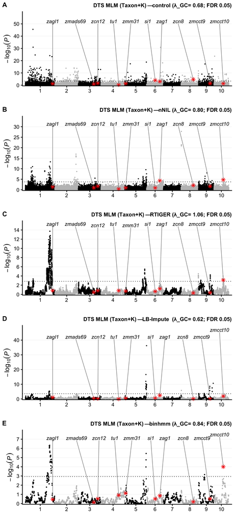

```r
panels <- lapply(names(callers), function(nm) {
  sc <- fread(here(sprintf("data/zeal/dts_gwas_mlm_%s_donor_accession_snp50k.csv", callers[[nm]])))
  plot_manhattan(sc, sprintf("DTS MLM (Taxon+K) — %s (λ_GC = %.2f; FDR 0.05)", nm, lam(sc$P)), overlap_csv = overlap, lod = fdr_lod(sc$P))
})
cc <- cowplot::plot_grid(plotlist = panels, ncol = 1, labels = LETTERS[1:5], label_size = 18, align = "v", axis = "lr")
ggsave(here("results/sim/zeal/dts_caller_composite_fdr_snp50k.png"), cc, width = 9, height = 20, dpi = 200, bg = "white")
cc
```